# STAT 651: Homework 2

Author

Pavan Malapati

Load the necessary libraries

```r
library(tidyverse)
library(lubridate)
```

**Exercise 1**

```r
t1 <- mdy("10/31/2024")
t2 <- dmy("31-10-2024")
t3 <- mdy("October 31, 2024")

t1
```

```
[1] "2024-10-31"
```

```r
t2
```

```
[1] "2024-10-31"
```

```r
t3
```

```
[1] "2024-10-31"
```

**Exercise 2,a**

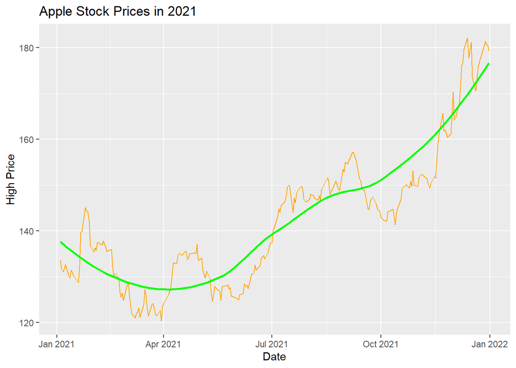

```r
tech_stock <- read_csv("tech_stock.csv",show_col_types = FALSE)

apple <- tech_stock %>%
  filter(company == "AAPL")

ggplot(apple, aes(x = date, y = high)) +
  geom_line(color = "orange") +
  geom_smooth(method = "loess", se = FALSE, color = "green") +
  labs(
    title = "Apple Stock Prices in 2021",
    x = "Date",
    y = "High Price"
  )
```

The graph shows how Apple’s stock price changed in 2021. Overall, the price went up, The smooth green line shows the general upward trend, while the orange line shows the actual daily prices. There might be a small pattern of the stock going down at the start of the year and then going up, but it’s not very clear. The spikes in the stock prices is in the second half of the year this may be due to the new product launch.

**Exercise 2,b**

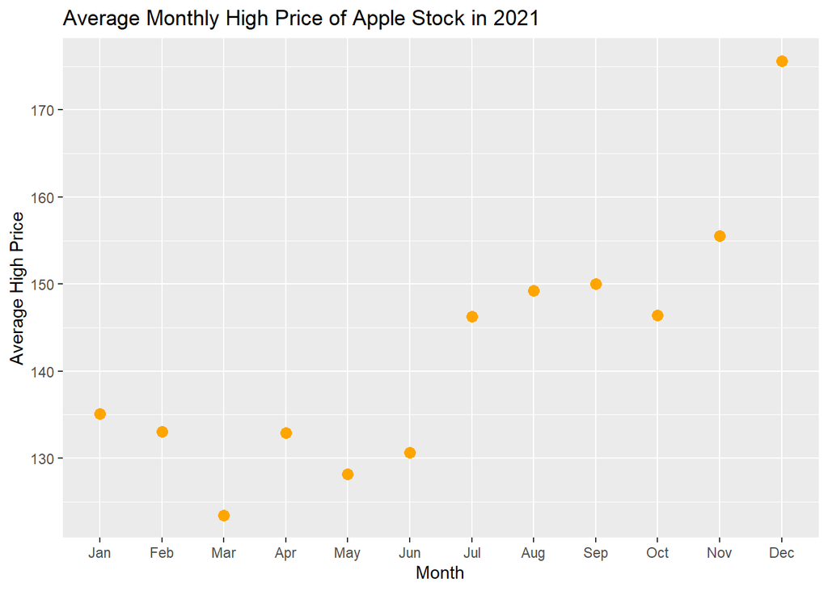

```r
a_m_a <- apple %>%
  mutate(month = month(date, label = TRUE, abbr = TRUE)) %>%
  group_by(month) %>%
  summarize(avg_high = mean(high, na.rm = TRUE))

ggplot(a_m_a, aes(x = month, y = avg_high)) +
  geom_point(color = "orange",size=3) +
  labs(
    title = "Average Monthly High Price of Apple Stock in 2021",
    x = "Month",
    y = "Average High Price"
  )
```

**Exercise 3**

```r
sfcrimes2023 <- readRDS(url("https://ericwfox.github.io/data/sfcrimes2023.rds"))
glimpse(sfcrimes2023)
```

```
Rows: 132,914
Columns: 6
$ id              <dbl> 1231769, 1231872, 1233075, 1234053, 1234109, 1234242, …
$ datetime        <chr> "2023/01/01 12:00:00 AM", "2023/01/01 12:00:00 AM", "2…
$ category        <chr> "Burglary", "Larceny Theft", "Other", "Larceny Theft",…
$ police_district <chr> "Northern", "Bayview", "Taraval", "Southern", "Souther…
$ latitude        <dbl> 37.77206, 37.74220, 37.71369, 37.82452, 37.77403, 37.7…
$ longitude       <dbl> -122.4271, -122.4004, -122.4984, -122.3756, -122.3956,…
```

**Exercise 3,a**

```r
larceny_theft <- sfcrimes2023 %>%
  filter(category == "Larceny Theft") %>%
  mutate(datetime = ymd_hms(datetime, tz = "America/Los_Angeles"))

head(larceny_theft)
```

```
# A tibble: 6 × 6
       id datetime            category      police_district latitude longitude
    <dbl> <dttm>              <chr>         <chr>              <dbl>     <dbl>
1 1231872 2023-01-01 00:00:00 Larceny Theft Bayview             37.7     -122.
2 1234053 2023-01-01 00:00:00 Larceny Theft Southern            37.8     -122.
3 1234242 2023-01-01 00:00:00 Larceny Theft Mission             37.8     -122.
4 1234755 2023-01-01 00:00:00 Larceny Theft Northern            37.8     -122.
5 1236245 2023-01-01 00:00:00 Larceny Theft Mission             37.7     -122.
6 1237720 2023-01-01 00:00:00 Larceny Theft Tenderloin          37.8     -122.
```

**Exercise 3,b**

```r
larceny_theft <- larceny_theft %>%
  mutate(
    date = as.Date(datetime),
    month = month(datetime, label = TRUE),
    weekday = wday(datetime, label = TRUE, abbr = TRUE),
    hour = hour(datetime)
  )

head(larceny_theft)
```

```
# A tibble: 6 × 10
       id datetime            category      police_district latitude longitude
    <dbl> <dttm>              <chr>         <chr>              <dbl>     <dbl>
1 1231872 2023-01-01 00:00:00 Larceny Theft Bayview             37.7     -122.
2 1234053 2023-01-01 00:00:00 Larceny Theft Southern            37.8     -122.
3 1234242 2023-01-01 00:00:00 Larceny Theft Mission             37.8     -122.
4 1234755 2023-01-01 00:00:00 Larceny Theft Northern            37.8     -122.
5 1236245 2023-01-01 00:00:00 Larceny Theft Mission             37.7     -122.
6 1237720 2023-01-01 00:00:00 Larceny Theft Tenderloin          37.8     -122.
# ℹ 4 more variables: date <date>, month <ord>, weekday <ord>, hour <int>
```

**Exercise 3,c**

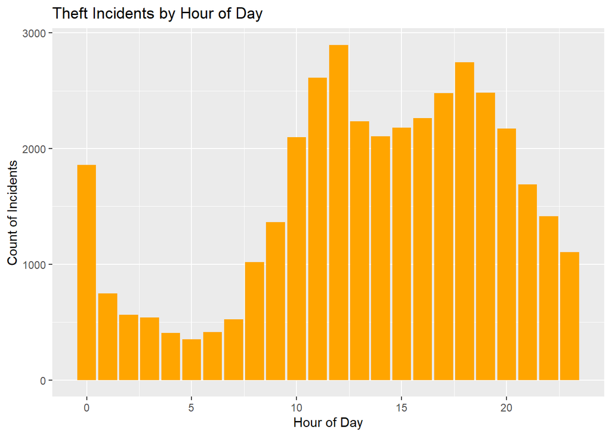

```r
ggplot(larceny_theft, aes(x = hour)) +
  geom_bar(fill = "orange") +
  labs(
    title = "Theft Incidents by Hour of Day",
    x = "Hour of Day",
    y = "Count of Incidents"
  )
```

**Exercise 3,d**